# Stratified Random Sampling of Schools

Juda Kaleta

2024-06-28

Our study aims to employ stratified random sampling to select a representative sample of Czech schools at ISCED level 2. The sampling process ensures proportional representation based on school size, determined by the number of students.

# Population Definition

The target population consists of Czech schools at ISCED level 2 that meet the following criteria:

- The type of the school is `B10` (normal school).
- The school is fully organized.
- The school had a non-zero number of students in the given year.

```r
data <- read_excel(file_path, sheet = "v0324jc1")

population <- data %>%
  filter(
    TYP == "B10",                          # only normal schools
    org == 1,                              # only fully organized schools
    !!sym(col_total_students_count) > 0,   # filter out empty schools
  )
```

The table below provides a summary of the target population of schools based on the given criteria.

```r
summary_population <- population %>%
  summarize(
    total_schools = n(),
    min_students = min(!!sym(col_total_students_count)),
    max_students = max(!!sym(col_total_students_count)),
    mean_students = mean(!!sym(col_total_students_count)),
    median_students = median(!!sym(col_total_students_count))
  )

kable(summary_population, caption = "Summary of the Target Population")
```

Summary of the Target Population

| total_schools | min_students | max_students | mean_students | median_students |
| --- | --- | --- | --- | --- |
| 2486 | 14 | 1208 | 338.3797 | 302 |

The histogram below shows the distribution of the number of students in the target population of schools.

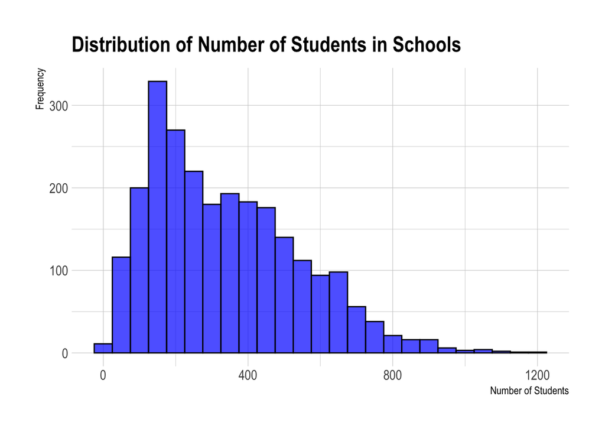

```r
# Create a histogram of the number of students in schools
ggplot(population, aes(x = !!sym(col_total_students_count))) +
  geom_histogram(binwidth = 50, fill = "blue", color = "black", alpha = 0.7) +
  labs(title = "Distribution of Number of Students in Schools",
       x = "Number of Students",
       y = "Frequency") +
  theme_ipsum()
```

# Stratification Criteria

The stratified sample is selected based on school size (number of students). Schools are divided into 3 groups using Jenks natural breaks. This method optimally partitions the data into homogeneous groups, ensuring that each stratum contains schools with similar sizes.

```r
jenks_breaks <- classIntervals(population[[col_total_students_count]], n = n_strata, style = "jenks")
breaks <- jenks_breaks$brks
```

To assign each school to a corresponding stratum based on the Jenks breaks, we create a new column in the population dataset.

```r
# Create a new column for strata based on the breaks
population <- population %>%
  mutate(
    strata = cut(
      !!sym(col_total_students_count),
      breaks = breaks,
      include.lowest = TRUE,
      labels = (seq_along(breaks) - 1)[-1]
    )
  )
```

We can then summarize the population within each stratum to understand the distribution of school sizes across the different strata.

```r
summary_population_strata <- population %>%
  group_by(strata) %>%
  summarize(
    total_schools = n(),
    min_students = min(!!sym(col_total_students_count)),
    max_students = max(!!sym(col_total_students_count)),
    mean_students = mean(!!sym(col_total_students_count)),
    median_students = median(!!sym(col_total_students_count))
  )

kable(summary_population_strata, caption = "Summary of the Target Population by Strata")
```

Summary of the Target Population by Strata

| strata | total_schools | min_students | max_students | mean_students | median_students |
| --- | --- | --- | --- | --- | --- |
| 1 | 1182 | 14 | 284 | 165.9010 | 164.0 |
| 2 | 864 | 285 | 538 | 403.8160 | 400.5 |
| 3 | 440 | 539 | 1208 | 673.2273 | 641.0 |

To visualize the distribution of the number of students in schools and the resulting Jenks breaks, we create a histogram with the break points indicated.

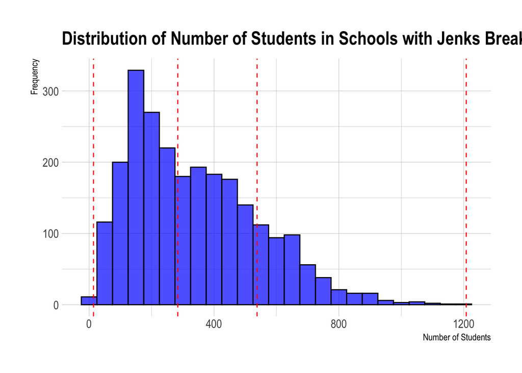

```r
ggplot(population, aes(x = !!sym(col_total_students_count))) +
  geom_histogram(binwidth = 50, fill = "blue", color = "black", alpha = 0.7) +
  geom_vline(xintercept = breaks, linetype = "dashed", color = "red") +
  labs(title = "Distribution of Number of Students in Schools with Jenks Breaks",
       x = "Number of Students",
       y = "Frequency") +
  theme_ipsum()
```

# Sample Size Determination

To determine the appropriate sample size, we use Cochran’s equation. This method provides a way to calculate a statistically valid sample size based on the desired confidence level, margin of error, and estimated proportion of the population.

```r
cochran_sample_size <- function(population_size, confidence_level = 0.95, margin_of_error = 0.05, estimated_proportion = 0.5) {
  # Calculate Z-value for the desired confidence level
  z_value <- qnorm(1 - (1 - confidence_level) / 2)

  # Calculate Cochran's sample size
  n_0 <- (z_value^2 * estimated_proportion * (1 - estimated_proportion)) / (margin_of_error^2)

  # Adjust sample size for finite population
  sample_size <- n_0 / (1 + (n_0 - 1) / population_size)

  return(round(sample_size))
}
```

Next, we calculate the total sample size needed for our study using the function defined above.

```r
population_size <- nrow(population)
total_sample_size <- cochran_sample_size(population_size)
```

The total sample size required is 333 schools. We then compute the sample size for each stratum to ensure proportional representation.

```r
strata_sample_sizes <- population %>%
  group_by(strata) %>%
  summarize(
    stratum_size = n(),
    stratum_sample_size = round((stratum_size / population_size) * total_sample_size)
  )

population <- population %>%
  left_join(strata_sample_sizes, by = "strata")

kable(strata_sample_sizes, caption = "Sample Sizes for Each Stratum")
```

Sample Sizes for Each Stratum

| strata | stratum_size | stratum_sample_size |
| --- | --- | --- |
| 1 | 1182 | 158 |
| 2 | 864 | 116 |
| 3 | 440 | 59 |

# Sampling Procedure

We use stratified random sampling to select schools within each stratum based on the predetermined sample sizes.

```r
set.seed(123)  # For reproducibility
sampled_schools <- population %>%
  group_by(strata) %>%
  group_modify(~ slice_sample(.x, n = min(.x$stratum_sample_size[1], nrow(.x))))
```

We save the sampled schools to an RData file for future analysis and reference.

```r
save(sampled_schools, file = "../outcomes/sampled_schools.RData")

# Save the sampled schools to a CSV file, including only specified columns
csv_export_columns <- sampled_schools %>%
  select(strata, izo, zar_naz, ulice, misto)

write.csv(csv_export_columns, file = "../outcomes/sampled_schools.csv", row.names = FALSE)
```

We visualize the distribution of the number of students in both the sampled schools and the entire population to compare their distributions.

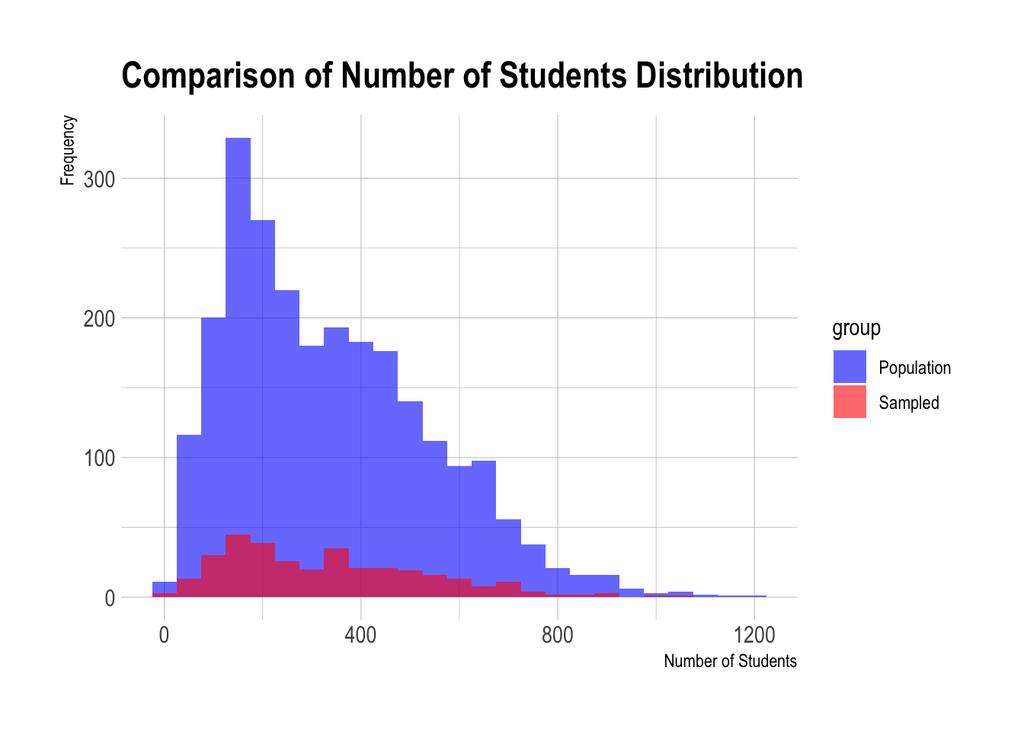

```r
# Combine population and sampled schools for visualization
population$group <- "Population"
sampled_schools$group <- "Sampled"

combined_data <- bind_rows(population, sampled_schools)

# Plot histogram
ggplot(combined_data, aes(x = !!sym(col_total_students_count), fill = group)) +
  geom_histogram(position = "identity", alpha = 0.6, binwidth = 50) +
  labs(title = "Comparison of Number of Students Distribution",
       x = "Number of Students",
       y = "Frequency") +
  scale_fill_manual(values = c("Population" = "blue", "Sampled" = "red")) +
  theme_ipsum()
```